# Reproducible Research: Peer Assessment 1

Jinghong

December 12, 2015

## Loading and preprocessing the data

Download and unzip the data, then load the data into workspace.

```r
temp <- tempfile()
download.file("https://d396qusza40orc.cloudfront.net/repdata%2Fdata%2Factivity.zip",temp)
activity_raw <- read.csv(unz(temp, "activity.csv"))
unlink(temp)
```

Remove NA values.

```r
activity <- activity_raw[complete.cases(activity_raw),]
```

## What is mean total number of steps taken per day?

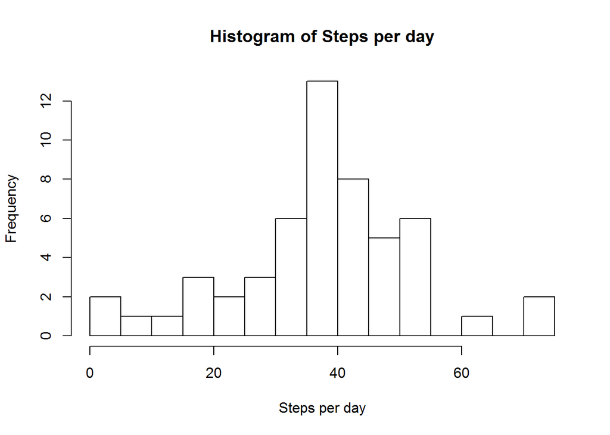

```r
stepsPday <- tapply(activity$steps, activity$date, mean)
hist(stepsPday, breaks = 20, xlab = 'Steps per day', main = 'Histogram of Steps per day')
```

```r
mean(stepsPday, na.rm = TRUE)
```

```
## [1] 37.3826
```

```r
median(stepsPday, na.rm = TRUE)
```

```
## [1] 37.37847
```

## What is the average daily activity pattern?

Make a time series plot (i.e. type = “l”) of the 5-minute interval (x-axis) and the average number of steps taken, averaged across all days (y-axis)

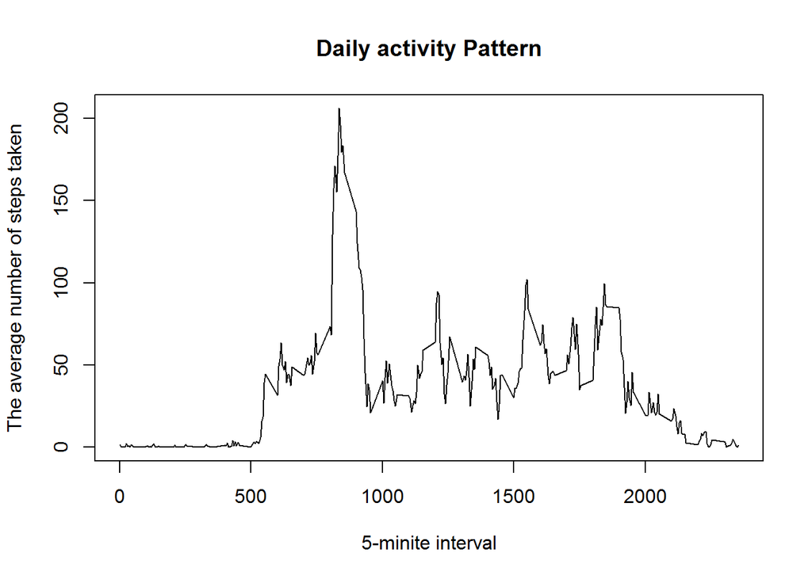

```r
stepsPattern <- tapply(activity$steps, activity$interval, mean)
plot(unique(activity$interval), stepsPattern, type = "l", main = 'Daily activity Pattern', xlab = '5-minite interval', ylab = 'The average number of steps taken')
```

Which 5-minute interval, on average across all the days in the dataset, contains the maximum number of steps?

```r
which.max(stepsPattern)
```

```
## 835
## 104
```

## Imputing missing values

Calculate and report the total number of missing values in the dataset (i.e. the total number of rows with NAs)

```r
sum(is.na(activity_raw))
```

```
## [1] 2304
```

```r
activity_fill <- activity_raw
activity_fill$steps[which(is.na(activity_raw))] <- mean(stepsPattern)
```

Make a histogram of the total number of steps taken each day and Calculate and report the mean and median total number of steps taken per day.

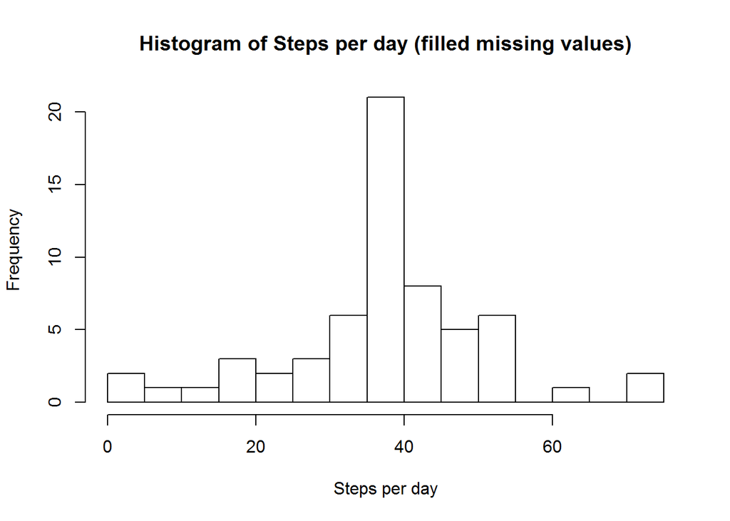

```r
stepsPday_fill <- tapply(activity_fill$steps, activity_fill$date, mean)
hist(stepsPday_fill, breaks = 20, xlab = 'Steps per day', main = 'Histogram of Steps per day (filled missing values)')
```

```r
mean(stepsPday_fill, na.rm = TRUE)
```

```
## [1] 37.3826
```

```r
median(stepsPday_fill, na.rm = TRUE)
```

```
## [1] 37.3826
```

We can see that since we imput the missing values with its mean, the histgram is more center than before. And the median value approximates the mean.

## Are there differences in activity patterns between weekdays and weekends?

Create a new factor variable in the dataset with two levels - “weekday” and “weekend” indicating whether a given date is a weekday or weekend day.

```r
#create a vector of weekdays
weekdays <- c('Monday', 'Tuesday', 'Wednesday', 'Thursday', 'Friday')
#Use `%in%` and `weekdays` to create a logical vector
#convert to `factor` and specify the `levels/labels`
activity_fill$wDay <- factor(weekdays(as.Date(activity_fill$date)) %in% weekdays,
         levels=c(FALSE, TRUE), labels=c('weekend', 'weekday'))
```

Make a panel plot containing a time series plot (i.e. type = “l”) of the 5-minute interval (x-axis) and the average number of steps taken, averaged across all weekday days or weekend days (y-axis).

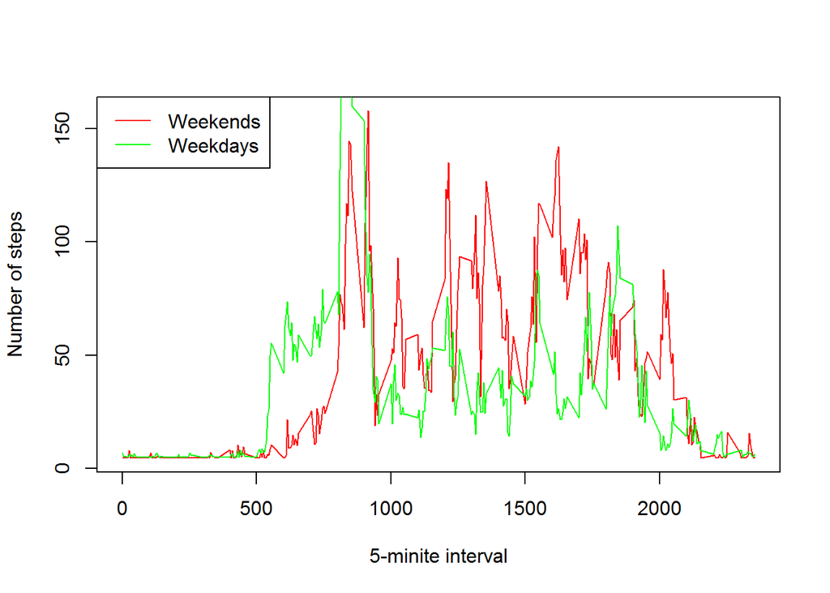

```r
stepsWDay <- tapply(activity_fill$steps, list(activity_fill$interval, activity_fill$wDay), mean)
plot(unique(activity_fill$interval), stepsWDay[,1], type = "l", xlab = '5-minite interval', ylab = 'Number of steps', col = "red")
lines(unique(activity_fill$interval),stepsWDay[,2],col="green")
legend('topleft',  c('Weekends','Weekdays'), lty = 1, col = c('red', 'green'))
```

This person conducts more activities during the weekends, but does excercises during weekdays morning as well. Based the above information. This person probably sits in front of a computer whole day during workdays.